# Part II - Presentation of findings from the exploration of Loan Data from Prosper

## by Chikadibia F. Ezeh

## Investigation Overview

> The overall goal of this presentation is to show the result of the explotaions performed on loan data from prosper. The exploration was performed to investigate the overall performance of the listed credits in the dataset.

> It was found that most of the prevous debts of borrowers in the listing were consolidated. i.e credits listed to settle prevous debts, as such, the overall credit performance picture was a good one.

## Dataset Overview

> The loan data from prosper is a dataset which contains 113,937 loans with 81 variables on each loan, including loan amount, borrower rate (or interest rate), current loan status, borrower income, and many others.

> The original dataset had the shape (113937, 81), i.e. 113,937 loans with 81 attributes (columns). preliminary data wrangling restricted the shape to (96187, 16), 16 selected attributes (columns) from the original dataset (among which includes both discrete and continuous variables), few of which were eventualy dropped and 3 attributes (MedianScore, CreditRating, listingcategory) are outcomes from feature engineering.

## Univariate visualization for the transformed EmploymentStatus

### Transformation of the employment status variable

> The employment status column contains several kinds (employed, full-time, part time and self employed). The employmnet status column was transformed to merge these various kinds of eployments into one called 'Employed' and we now have employment status to be either employed, not employed, others, or retired.

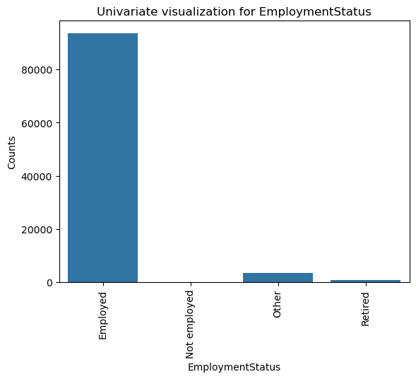

## Univariate visualization for transformed LoanStatus

### Transformation of loan status variable

> The loan status column contained various forms of delinquencies according to whether defaulted and the number of days past due. These various kinds of deliquency were transformed to be called 'Delinquent'. Also, the credits in the final repayment stage were merged with current ones so that the loan status are now, cancelled, completed, charged off, current and delinquent.

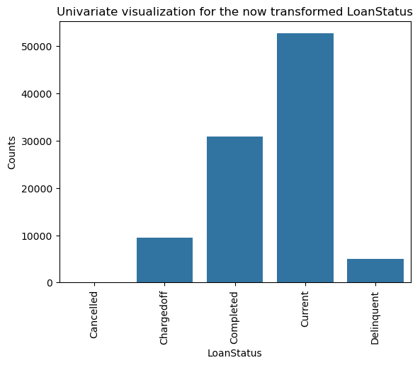

## Visualization for credit ratings

### Transformation of upper and lower credit scores to median score and then to credit ratings

> The original dataset contained two different columns for credit scores (upper credit score and lower credit score). The medians for these credit scores were taken as good representatives of the credit score intervals resulting to one column called 'medianscore'. On this median score column, the FICO credit score rating system was applied to get another column called 'Creditrating'. It is from this credit column that visualization was done.

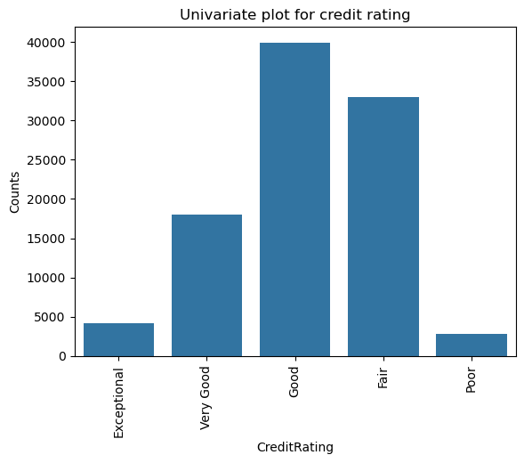

## Visualization to compare employment status and credit rating

> The employment status and the credit rating were compared to view the relationship between them. We found that the credit ratings were generally good. It is speculated that the reason why the credit ratings are generally good is customers involved in the listed credits borrowed funds for the consolidation of old debts. These consolidation was confirmed, given that majority of the loans given to the employed customers are current and are found in the debt consolidation category.

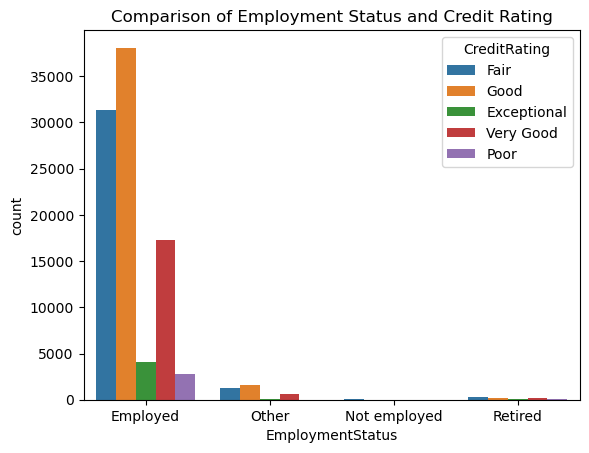

## Relationship between CreditRating, ListingCategory, LoanStatus

> It is confirmed that majority of the credits currently running are for debt consolidation

> A significant count of the credit items are charged off

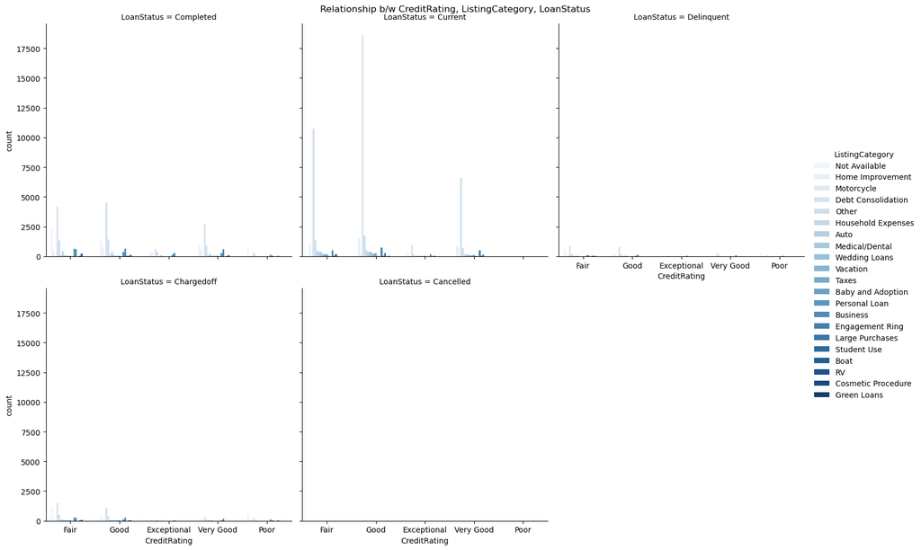

## Visualization to compare RevolvingCreditBalance, OpenRevolvingMonthlyPayment, and AmountDelinquent

> Amounts Delinquent are more concetrated in the lower range, say 0 to 100,000 and sparsely distributed as we go up the legend

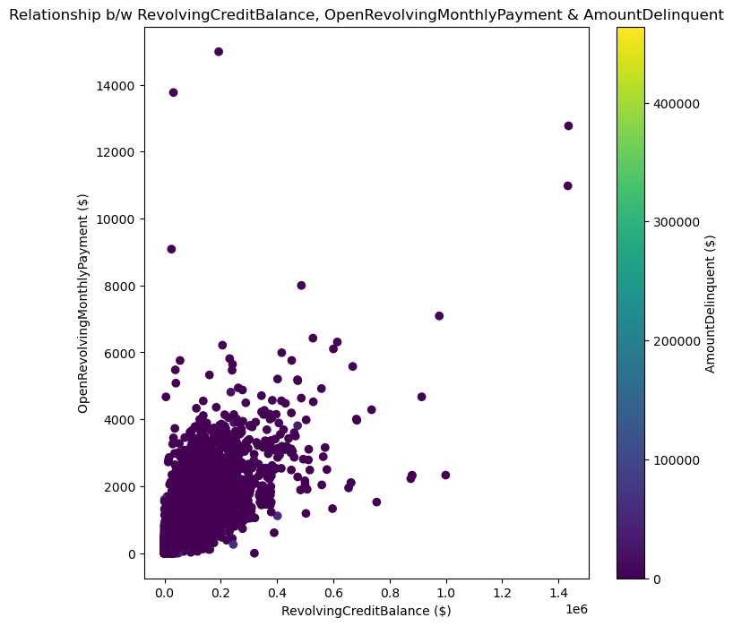

## Visualization comparing LoanStatus, AmountDelinquent, and EmploymentStatus

> The amount delinquent accross all employment status have majorly charged off and completed loan status in that order

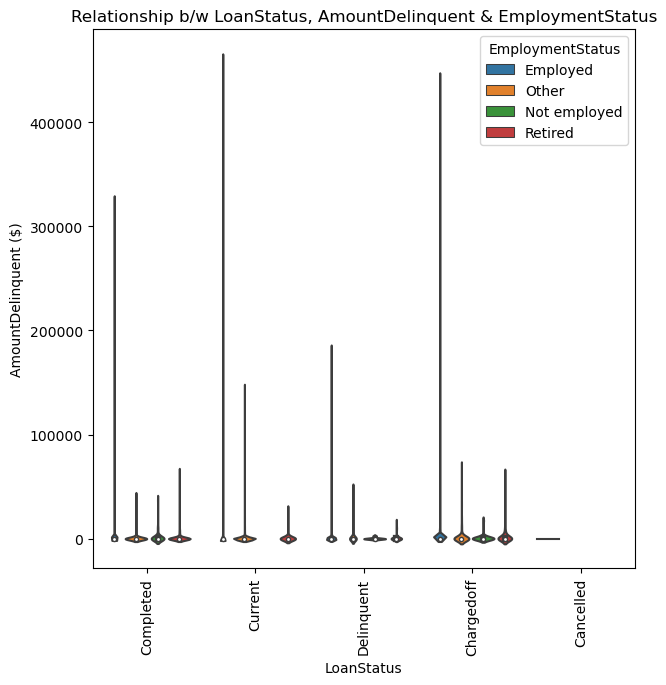